# S8: Analysis using brain data simulated with the Shaefer200 atlas

| Analysis | Atlas (Number of regions) | Rdonor | Brain data | Gene set | Association | Null model type | Aggregation method |
| --- | --- | --- | --- | --- | --- | --- | --- |
| S8 | Shaefer200 (100) | 0.4 | 1000 simulated maps (Moran's I=0.03) | 500 simulated gene sets | Pearson Correlation | Competitive / Self-contained | Mean, Meanabs, Meansqr, Maxmean, Median, Sig Number, KS, Weighted KS |

## 0. Setup

```r
project_path='F:/Google Drive/post-doc/vitural_histology_revisit/revision_code'

sim_res_path=sprintf('%s/results',project_path)
result.path=sprintf('%s/reports',project_path)

atlas='schaefer200'
rdonor='r0.4'
brain_type='sim_spatial0.03'
gene_set_type='Sim'
cor_type='pearson'
null_type_level=c('random_gene',
                   'spin_brain')
null_type_label=c('Competitive null model',
                   'Self-contained null model')
stat_level=c('mean',
            'meanabs',
            'meansqr',
            'maxmean',
            'median',
            'sig_n',
            'ks_orig',
            'ks_weighted')
stat_label=c('Mean',
            'Meanabs',
            'Meansqr',
            'Maxmean',
            'Median',
            'Sig Number',
            'KS',
            'Weighted KS')
```

## 1. Load functions

```r
library(knitr)
library(kableExtra)
source(sprintf('%s/functions/analysis_functions.R',project_path))
source(sprintf('%s/functions/data_functions.R',project_path))
source(sprintf('%s/functions/cor_functions.R',project_path))
```

## 2. Load Results

```r
# get the list of csv files
res.files=list(
  spin_brain=sprintf( '%s/Res_%s_%s_%s_%s_spin_brain_%s_sim1000.csv',sim_res_path,atlas,rdonor,brain_type,gene_set_type,cor_type),
  random_gene=sprintf('%s/Res_%s_%s_%s_%s_random_gene_%s_sim1000.csv',sim_res_path,atlas,rdonor,brain_type,gene_set_type,cor_type))
# read res.files
res.df.list=lapply(res.files, read.csv, stringsAsFactors = F)
```

## 3. Psig-G analysis

```r
# Extract pvals and group them by geneSet
# Psig-G is calculated for each gene set
nest_by='geneSet'
pvals.nested=lapply(res.df.list, get_pvals_nested, nest_by=nest_by, heat_plot=F)
psig.list=lapply(pvals.nested, get_psig, if_fdr=F)
```

### 3.1.Plot Psig-G

#### Figure 2. A. Probability of significance for each gene set (Psig-G). B. Mean value and standard error (i.e., standard deviation/√500) of Psig-G across all the gene sets.

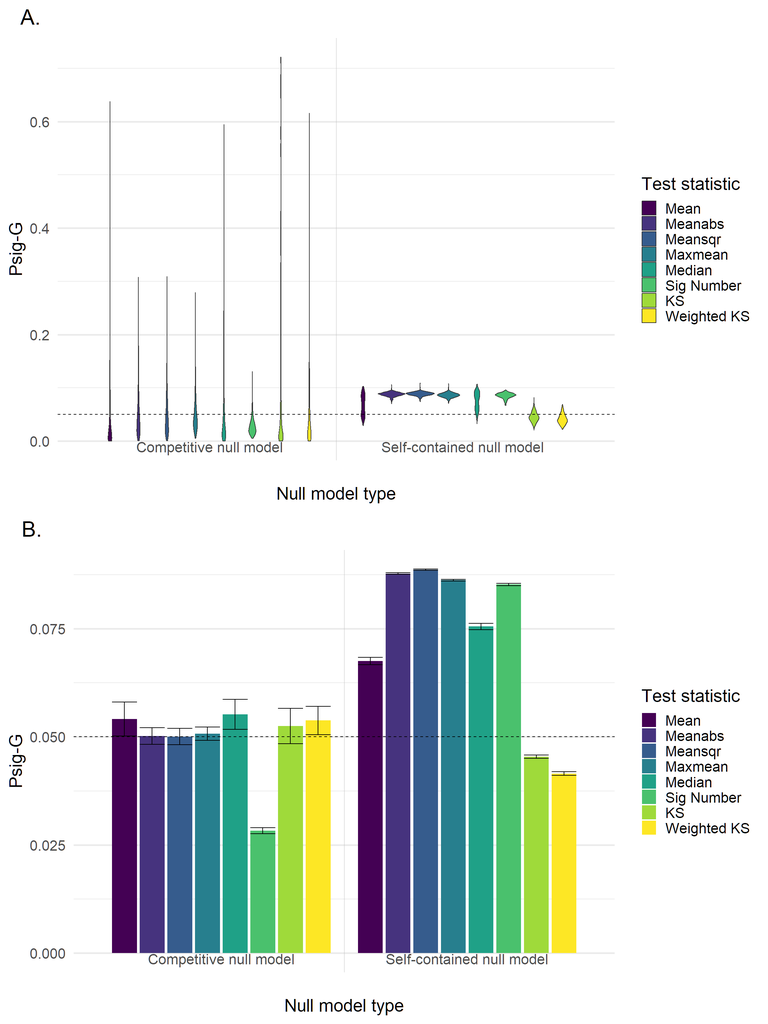

```r
p1=plot_violin_psig_list(psig.list = psig.list,
                         ylab2show = 'Psig-G',
                         title2show = 'A.',
                         title_adj = -0.07,
                         stat_level = stat_level,
                         stat_label = stat_label,
                         null_type_level = null_type_level,
                         null_type_label = null_type_label)
p2=plot_bar_psig_list(psig.list,
                        ylab2show='Psig-G',
                        title2show = 'B.',
                        title_adj = -0.1,
                        stat_level = stat_level,
                         stat_label = stat_label,
                         null_type_level = null_type_level,
                         null_type_label = null_type_label)
grid.arrange(p1,p2,ncol=1)
```

### 3.2.Examining the correlation between co-expression and Psig-G

```r
coexp_info=get_geneSetList_info(data_path=sprintf('%s/data',project_path),
                                 gs_type=gene_set_type,
                                 atlas=atlas,
                                 rdonor=rdonor)
coexp_res.nested.list=lapply(psig.list, correlate_psig_with_info,info=coexp_info,var2test='coexp_mean')
coexp_res.report.list=lapply(coexp_res.nested.list, report_res.nested)
coexp_res.plot.list=lapply(coexp_res.nested.list,
                           plot_res.nested,
                           xlim2show=c(-0.02,0.11),
                           annot_position=c(-0.01,0.5))
```

### 3.2.1. Plot correlation between co-expression and Psig-G

#### Figure 3. Results of co-expression analysis for the competitive (A) and self-contained null model (B). The x-axis indicates the co-expression of a specific gene set and the y-axis indicates the probability of significance for a specific gene set (Psig-G). Each dot denotes a specific gene set with the lighter color denoting the larger size of the gene set. The horizontal dashed line denotes a Psig-G of 0.05.

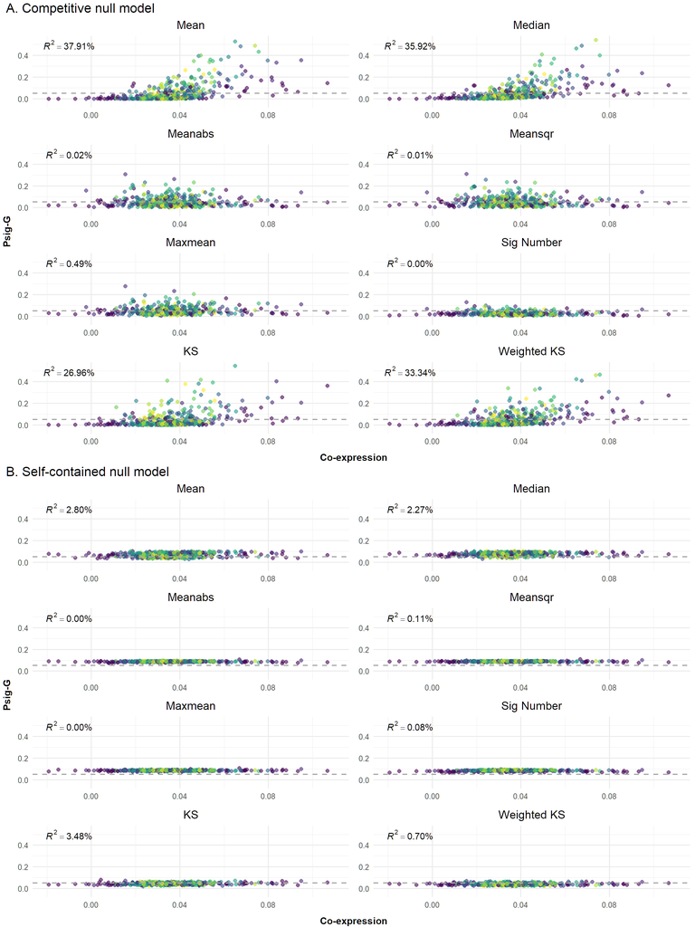

```r
p3=grid.arrange(grobs=coexp_res.plot.list[[null_type_level[1]]],
                ncol=2,
                top = textGrob(sprintf("A. %s",null_type_label[1]),gp=gpar(fontsize=16,font=1),x = -0.01, hjust = 0),
                left =textGrob("Psig-G",gp=gpar(fontsize=12,font=2),rot=90),
                bottom=textGrob("Co-expression",gp=gpar(fontsize=12,font=2)))
p4=grid.arrange(grobs=coexp_res.plot.list[[null_type_level[2]]],
                ncol=2,
                top = textGrob(sprintf("B. %s",null_type_label[2]),gp=gpar(fontsize=16,font=1),x = -0.01, hjust = 0),
                left =textGrob("Psig-G",gp=gpar(fontsize=12,font=2),rot=90),
                bottom=textGrob("Co-expression",gp=gpar(fontsize=12,font=2)))
grid.arrange(p3,p4)
```

### 3.2.2. Report correlation between co-expression and Psig-G

```r
df1=coexp_res.report.list[[null_type_level[1]]]
df2=coexp_res.report.list[[null_type_level[2]]]
kable(df1,caption = sprintf("A. %s",null_type_label[1]))%>%
  kable_styling(full_width = FALSE, position = "float_left")
kable(df2,caption = sprintf("B. %s",null_type_label[2]))%>%
  kable_styling(full_width = FALSE, position = "left")
```

A. Competitive null model

| Test statistic | t value | p value | FDR p value | R-squared |
| --- | --- | --- | --- | --- |
| Mean | 17.4389317 | 0.0000000 | 0.0000000 | 37.91% |
| Median | 16.7070018 | 0.0000000 | 0.0000000 | 35.92% |
| Meanabs | 0.3113665 | 0.7556523 | 0.9086970 | 0.02% |
| Meansqr | -0.1929599 | 0.8470691 | 0.9086970 | 0.01% |
| Maxmean | 1.5701722 | 0.1170102 | 0.1872163 | 0.49% |
| sig_n | 0.1147406 | 0.9086970 | 0.9086970 | 0.00% |
| KS | 13.5595019 | 0.0000000 | 0.0000000 | 26.96% |
| Weighted KS | 15.7829758 | 0.0000000 | 0.0000000 | 33.34% |

B. Self-contained null model

| Test statistic | t value | p value | FDR p value | R-squared |
| --- | --- | --- | --- | --- |
| Mean | 3.7874792 | 0.0001708 | 0.0006831 | 2.80% |
| Median | 3.3997552 | 0.0007286 | 0.0019430 | 2.27% |
| Meanabs | 0.0092707 | 0.9926069 | 0.9926069 | 0.00% |
| Meansqr | -0.7330820 | 0.4638534 | 0.7188233 | 0.11% |
| Maxmean | -0.0347233 | 0.9723143 | 0.9926069 | 0.00% |
| sig_n | 0.6145729 | 0.5391175 | 0.7188233 | 0.08% |
| KS | 4.2342627 | 0.0000273 | 0.0002185 | 3.48% |
| Weighted KS | 1.8703237 | 0.0620253 | 0.1240505 | 0.70% |

## 4. Psig-B analysis

### 4.1. Plot Psig-B

#### Figure 4. A. Probability of significance for each simulated brain map (Psig-B). B. Mean value and standard error (i.e., standard deviation/√1000) of Psig-B across all the simulated brain maps.

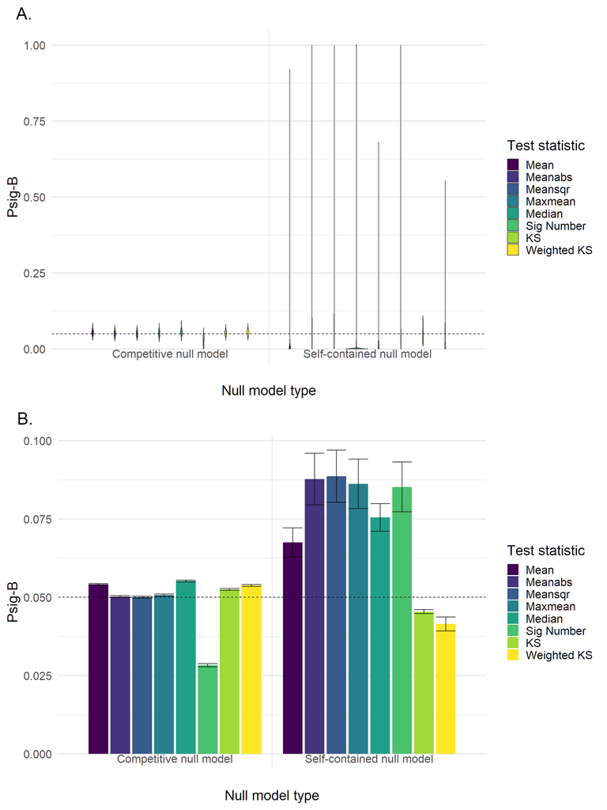

```r
p1=plot_violin_psig_list(psig.list = psig.list,
                         ylab2show = 'Psig-B',
                         title2show = 'A.',
                         title_adj = -0.086,
                         stat_level = stat_level,
                         stat_label = stat_label,
                         null_type_level = null_type_level,
                         null_type_label = null_type_label)
p2=plot_bar_psig_list(psig.list,
                        ylab2show='Psig-B',
                        title2show = 'B.',
                        title_adj = -0.1,
                        stat_level = stat_level,
                         stat_label = stat_label,
                         null_type_level = null_type_level,
                         null_type_label = null_type_label)
grid.arrange(p1,p2,ncol=1)
```

### 4.2. Examine the correlation between BI-dip and Psig-B

```r
# `var2test='pos_neg_dist'` is for BI-dist `var2test='modetest_stat'` is for BI-dip. default method is dip test
brain_info=get_brain_info(data_path=sprintf('%s/data',project_path),
                          atlas=atlas,
                          rdonor=rdonor,
                          brain_type=brain_type,
                          method=cor_type)
brain_res.nested.list=lapply(psig.list, correlate_psig_with_info,info=brain_info,var2test='modetest_stat')
brain_res.report.list=lapply(brain_res.nested.list, report_res.nested)
brain_res.plot.list=lapply(brain_res.nested.list,plot_res.nested,
                           annot_position=c(0.005,0.95),
                           xlim2show=c(-0.005,0.084),# max is 0.0837
                           ylim2show=c(-0.05,1))
```

### 4.2.1. Plot correlation between Psig-B and BI-dip

#### Figure 5. Results of the bimodality analysis for the competitive (A) and self-contained null model (B). The x-axis indicates the bimodality of the correlations between a specific brain map and transcriptional profiles of background genes, which was measured using the dip test statistic. The y-axis indicates the probability of significance for a specific brain map (Psig-B). Each dot denotes a brain map and the horizontal dashed line denotes a Psig-B value of 0.05.

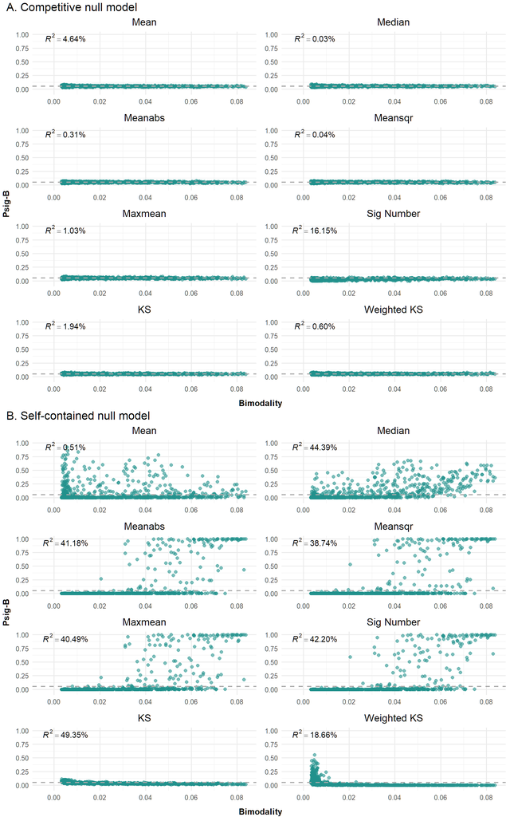

```r
p3=grid.arrange(grobs=brain_res.plot.list[[null_type_level[1]]],
                ncol=2,
                top = textGrob(sprintf("A. %s",null_type_label[1]),gp=gpar(fontsize=16,font=1),x = -0.01, hjust = 0),
                left =textGrob("Psig-B",gp=gpar(fontsize=12,font=2),rot=90),
                bottom=textGrob("Bimodality",gp=gpar(fontsize=12,font=2)))
p4=grid.arrange(grobs=brain_res.plot.list[[null_type_level[2]]],
                ncol=2,
                top = textGrob(sprintf("B. %s",null_type_label[2]),gp=gpar(fontsize=16,font=1),x = -0.01, hjust = 0),
                left =textGrob("Psig-B",gp=gpar(fontsize=12,font=2),rot=90),
                bottom=textGrob("Bimodality",gp=gpar(fontsize=12,font=2)))
grid.arrange(p3,p4)
```

### 4.2.2. Report correlation between Psig-B and BI-dip

```r
df1=brain_res.report.list[[null_type_level[1]]]
df2=brain_res.report.list[[null_type_level[2]]]
kable(df1,caption = sprintf("A. %s",null_type_label[1]))%>%
  kable_styling(full_width = FALSE, position = "float_left")
kable(df2,caption = sprintf("B. %s",null_type_label[2]))%>%
  kable_styling(full_width = FALSE, position = "left")
```

A. Competitive null model

| Test statistic | t value | p value | FDR p value | R-squared |
| --- | --- | --- | --- | --- |
| Mean | -6.9682272 | 0.0000000 | 0.0000000 | 4.64% |
| Median | -0.5311424 | 0.5954383 | 0.5954383 | 0.03% |
| Meanabs | -1.7500008 | 0.0804255 | 0.1072340 | 0.31% |
| Meansqr | -0.6616059 | 0.5083765 | 0.5810018 | 0.04% |
| Maxmean | -3.2203593 | 0.0013217 | 0.0026433 | 1.03% |
| sig_n | 13.8652153 | 0.0000000 | 0.0000000 | 16.15% |
| KS | -4.4453879 | 0.0000098 | 0.0000260 | 1.94% |
| Weighted KS | -2.4584017 | 0.0141247 | 0.0225995 | 0.60% |

B. Self-contained null model

| Test statistic | t value | p value | FDR p value | R-squared |
| --- | --- | --- | --- | --- |
| Mean | 2.271939 | 0.0233023 | 0.0233023 | 0.51% |
| Median | 28.225981 | 0.0000000 | 0.0000000 | 44.39% |
| Meanabs | 26.430675 | 0.0000000 | 0.0000000 | 41.18% |
| Meansqr | 25.124381 | 0.0000000 | 0.0000000 | 38.74% |
| Maxmean | 26.057218 | 0.0000000 | 0.0000000 | 40.49% |
| sig_n | 26.993524 | 0.0000000 | 0.0000000 | 42.20% |
| KS | -31.184168 | 0.0000000 | 0.0000000 | 49.35% |
| Weighted KS | -15.129016 | 0.0000000 | 0.0000000 | 18.66% |

### 4.3. Examine the correlation between BI-dist and Psig-B

```r
# `var2test='pos_neg_dist'` is for BI-dist `var2test='modetest_stat'` is for BI-dip. default method is dip test
brain_res.nested.list=lapply(psig.list, correlate_psig_with_info,info=brain_info,var2test='pos_neg_dist')
brain_res.report.list=lapply(brain_res.nested.list, report_res.nested)
brain_res.plot.list=lapply(brain_res.nested.list,plot_res.nested,
                           annot_position=c(0.115,0.95),
                           xlim2show=c(-0.02,1),
                           ylim2show=c(-0.05,1))
```